# statistics

*04_inferential_statistics/02_confidence_intervals/07_conf_int_z_raw_v1*

When Archie shoots archery, she records the horizontal position ($x$) and vertical position ($y$) of every arrow (in millimeters), using the bullseye as the origin.

From years of shooting, Archie has determined that $X$ and $Y$ are roughly bell-shaped with population standard deviations $\sigma_x = 53$ and $\sigma_y=55$ mm. However, Archie has a new sight, so her current population means ($\mu_x$ and $\mu_y$) are unknown. (She hopes both are zero.)

Archie wants to get confidence intervals for $\mu_x$ and $\mu_y$, using a sample size $n=6$ and a confidence level $\gamma=0.8$. Whether or not a confidence interval straddles 0 will determine whether Archie adjusts that aspect of her sight.

### Critical value

Determine the boundary $z^\star$ such that $P(|Z|<z^\star)=0.8$:

### Margins of error.

The margin of error represents how much variation we expect in sample means.
$$\text{ME}_x = \frac{z^\star \sigma_x}{\sqrt{n}}$$
$$\text{ME}_y = \frac{z^\star \sigma_y}{\sqrt{n}}$$
Calculate $\text{ME}_x$, the margin of error when sampling $\bar{x}$:

Calculate $\text{ME}_y$, the margin of error for sampling $\bar{y}$:

### Sample

Archie shoots $n=6$ arrows.

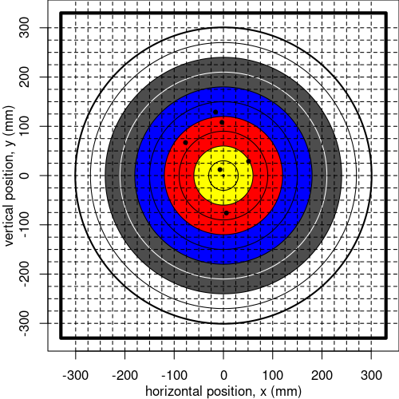

The exact positions can be downloaded as a csv.

### Sample means

Calculate $\bar{x}$, the horizontal sample mean:

Calculate $\bar{y}$, the vertical sample mean:

### Confidence intervals

Calculate the 80% confidence interval of $\mu_x$ by using $\bar{x}\pm\text{ME}_x$.

Calculate the lower boundary:

Calculate the upper boundary:

Calculate the 80% confidence interval of $\mu_y$ by using $\bar{y}\pm\text{ME}_y$.

Calculate the lower boundary:

Calculate the upper boundary:

### Inference

If a confidence interval straddles 0, Archie will leave that aspect alone. If a confidence interval does not straddle 0, Archie will adjust that aspect on the sight.

Does Archie adjust the horizontal aspect of her sight?

Yes / No

Does Archie adjust the vertical aspect of her sight?

Yes / No